**NOTE**: Functional Programming is covered in the course textbook. In these notes, we just provide the examples we covered in class with a few simple explanations. For more complete explanations, please refer to the [Functional Programming](http://book.cs-apps.org/functions/functions/index.html) chapter of the textbook.

# Functional programming vs. "functional languages"

Some languages are known as *functional programming languages*, as some languages are known as *object-oriented programming languages*. In practice, functional and object-oriented are more properly characterized as styles of programming instead of rigid categories of languages. It is rarely the case that a programming language itself only permits one style of programming; usually, languages are designed in order to facilitiate one or more styles of programming, but not often to forbid any other style.

Python is a multiparadigm language; it is designed to support object-oriented programming, functional programming, and even neither of the above. The Python programmer is not limited to a particular style, but rather has a full buffet of features to choose from. From a language design standpoint, if Python were a movie, it would be a four-hour long director's cut with the extra scenes left in, and very little left on the cutting room floor. This wide-open Pythonian landscape is not good or bad, in itself; it does mean that Python can accommodate different programming styles to such an extent that Python programmers cannot necessarily expect much common ground with one another just because their code is written in the same language.

In this lecture and the next one, we will provide context for functional programming, first by helping explain what the functional programming style consists of, and then by demonstrating functional programming in Python with motivating examples.

# Functions as parameters

Suppose we have a tree data structure like this. A tree with arbitrarily (finitely) many children under each parent node is commonly called a *rose tree*; we will use that terminology in our class definition here. More specifically, we will call this an *IntRoseTree* because it is a rose tree with integers at every node.

```python
from typing import Optional

class IntRoseTree:

    _root: int
    _children: list['IntRoseTree']

    def __init__(self, root: int):
        self._root = root
        self._children = []

    @property
    def is_leaf(self) -> bool:
        return len(self._children)==0

    def add_child(self, child: 'IntRoseTree') -> None:
        self._children.append(child)

    def num_children(self) -> int:
        return len(self._children)

    def __repr__(self) -> str:
        if self.is_leaf:
            return f'{self._root}'
        else:
            return f'{self._root}[{self._children}]'
```

Note how we use the dunder method `__repr__` to construct a string value of the tree. This method will be helpful during development, during testing and debugging especially.

Let's create a specific tree. Furthermore, let's make the tree construction a function so we can reconstruct the tree on demand as needed.

```python
def sample_tree() -> IntRoseTree:
    """
    Build this tree:

           10
          /  \
         /    \
        50     70
      / | \
     20 40 90
       /  \
     200  -40
    """
    t10: IntRoseTree  = IntRoseTree(10)
    t50: IntRoseTree  = IntRoseTree(50)
    t70: IntRoseTree  = IntRoseTree(70)
    t20: IntRoseTree  = IntRoseTree(20)
    t40: IntRoseTree  = IntRoseTree(40)
    t90: IntRoseTree  = IntRoseTree(90)
    t200: IntRoseTree = IntRoseTree(200)
    t_40: IntRoseTree = IntRoseTree(-40)
    t10.add_child(t50)
    t10.add_child(t70)
    t50.add_child(t20)
    t50.add_child(t40)
    t50.add_child(t90)
    t40.add_child(t200)
    t40.add_child(t_40)
    return t10
```

Let's create the tree and print its string representation.

```python
t = sample_tree()
print('t:',t)
```

```
t: 10[[50[[20, 40[[200, -40]], 90]], 70]]
```

One of the kinds of operations one might have cause to do with a tree -- in fact, with any collection data structure, like a list, set, dictionary, etc. -- is to systematically transform every piece of data in that tree (collection). For example, we might want to increase the value of every integer value in a tree. Let's say we added a method that increments (adds one to) every value in an IntRoseTree. We will at first perform this operation *destructively*, which is to say we will overwrite the values of the given tree such that every integer is replaced by an integer greater by 1. We use the name `incr_imp` to mean "increment, imperative style," because we call this destructive-update style of programming *imperative*.

```python
class IntRoseTree:

    _root: int
    _children: list['IntRoseTree']

    def __init__(self, root: int):
        self._root = root
        self._children = []

    @property
    def is_leaf(self) -> bool:
        return len(self._children)==0

    def add_child(self, child: 'IntRoseTree') -> None:
        self._children.append(child)

    def num_children(self) -> int:
        return len(self._children)

    def __repr__(self) -> str:
        if self.is_leaf:
            return f'{self._root}'
        else:
            return f'{self._root}[{self._children}]'

    def incr_imp(self) -> None:
        self._root += 1
        for child in self._children:
            child.incr_imp()

def sample_tree() -> IntRoseTree:
    t10: IntRoseTree  = IntRoseTree(10)
    t50: IntRoseTree  = IntRoseTree(50)
    t70: IntRoseTree  = IntRoseTree(70)
    t20: IntRoseTree  = IntRoseTree(20)
    t40: IntRoseTree  = IntRoseTree(40)
    t90: IntRoseTree  = IntRoseTree(90)
    t200: IntRoseTree = IntRoseTree(200)
    t_40: IntRoseTree = IntRoseTree(-40)
    t10.add_child(t50)
    t10.add_child(t70)
    t50.add_child(t20)
    t50.add_child(t40)
    t50.add_child(t90)
    t40.add_child(t200)
    t40.add_child(t_40)
    return t10
```

```python
t = sample_tree()
print('t:',t)
print('incrementing t...')
t.incr_imp()
print('t:',t)
print('incrementing t...')
t.incr_imp()
print('t:',t)
```

```
t: 10[[50[[20, 40[[200, -40]], 90]], 70]]
incrementing t...
t: 11[[51[[21, 41[[201, -39]], 91]], 71]]
incrementing t...
t: 12[[52[[22, 42[[202, -38]], 92]], 72]]
```

As we can see, this is working as expected.

Note that a consequence of doing a *destructive* update on the value of each node is that the original tree is, in a sense, no longer there -- every time we call `incr` on a tree, we get one step farther away from the tree in its original form. In contrast to imperative programming, we have a *functional* style, whereby the common practice is, rather than destroy old values in favor of new ones, we leave our old values alone and build *new* ones as needed. There are reasons for preferring one style or another, which will be an ongoing point of interest as we move along in the introductory curriculum. If we were to rewrite `IntRoseTree` and its `incr` operation in a functional style, i.e., without destructive updates, it would look like this:

```python
class IntRoseTree:

    _root: int
    _children: list['IntRoseTree']

    def __init__(self, root: int):
        self._root = root
        self._children = []

    @property
    def is_leaf(self) -> bool:
        return len(self._children)==0

    def add_child(self, child: 'IntRoseTree') -> None:
        self._children.append(child)

    def num_children(self) -> int:
        return len(self._children)

    def __repr__(self) -> str:
        if self.is_leaf:
            return f'{self._root}'
        else:
            return f'{self._root}[{self._children}]'

    def incr_func(self) -> IntRoseTree:
        t = IntRoseTree(self._root+1)
        for child in self._children:
            t.add_child(child.incr_func())
        return t

def sample_tree() -> IntRoseTree:
    t10: IntRoseTree  = IntRoseTree(10)
    t50: IntRoseTree  = IntRoseTree(50)
    t70: IntRoseTree  = IntRoseTree(70)
    t20: IntRoseTree  = IntRoseTree(20)
    t40: IntRoseTree  = IntRoseTree(40)
    t90: IntRoseTree  = IntRoseTree(90)
    t200: IntRoseTree = IntRoseTree(200)
    t_40: IntRoseTree = IntRoseTree(-40)
    t10.add_child(t50)
    t10.add_child(t70)
    t50.add_child(t20)
    t50.add_child(t40)
    t50.add_child(t90)
    t40.add_child(t200)
    t40.add_child(t_40)
    return t10
```

```python
t = sample_tree()
print(f't is {t}')
print(f't.incr_func() is {t.incr_func()}')
print(f't is {t}')
print(f't.incr_func().incr_func().incr_func() is {t.incr_func().incr_func().incr_func()}')
print(f't is {t}')
```

```
t is 10[[50[[20, 40[[200, -40]], 90]], 70]]
t.incr_func() is 11[[51[[21, 41[[201, -39]], 91]], 71]]
t is 10[[50[[20, 40[[200, -40]], 90]], 70]]
t.incr_func().incr_func().incr_func() is 13[[53[[23, 43[[203, -37]], 93]], 73]]
t is 10[[50[[20, 40[[200, -40]], 90]], 70]]
```

Notice that this design open up new possibilities for us. We can chain calls to `incr_func` together, since each call to `incr_func` returns a fresh tree, and furthermore, we still have the original tree in our possession unchanged at all times.

Depending on the application, these might be desirable properties, but of course they come at a cost. Building new objects takes time and space, so this paradigm is good only when time-and-space computing resources are abundant in relation to whatever the application is doing.

Now let's say we wanted to add a method to *double* the values in the tree. This is also a node-by-node arithmetic transformation. The same paradigm choices are available to us: we can write in an imperative style or a functional style, or, even, perhaps, both styles if we are willing to write two different methods. The following example code includes methods `double_imp` and `double_func`, written in imperative and functional styles, respectively.

```python
class IntRoseTree:

    _root: int
    _children: list['IntRoseTree']

    def __init__(self, root: int):
        self._root = root
        self._children = []

    @property
    def is_leaf(self) -> bool:
        return len(self._children)==0

    def add_child(self, child: 'IntRoseTree') -> None:
        self._children.append(child)

    def num_children(self) -> int:
        return len(self._children)

    def __repr__(self) -> str:
        if self.is_leaf:
            return f'{self._root}'
        else:
            return f'{self._root}[{self._children}]'

    def double_imp(self) -> None:
        self._root *= 2
        for child in self._children:
            child.double_imp()

    def double_func(self) -> IntRoseTree:
        t = IntRoseTree(self._root * 2)
        for child in self._children:
            t.add_child(child.double_func())
        return t

def sample_tree() -> IntRoseTree:
    t10: IntRoseTree  = IntRoseTree(10)
    t50: IntRoseTree  = IntRoseTree(50)
    t70: IntRoseTree  = IntRoseTree(70)
    t20: IntRoseTree  = IntRoseTree(20)
    t40: IntRoseTree  = IntRoseTree(40)
    t90: IntRoseTree  = IntRoseTree(90)
    t200: IntRoseTree = IntRoseTree(200)
    t_40: IntRoseTree = IntRoseTree(-40)
    t10.add_child(t50)
    t10.add_child(t70)
    t50.add_child(t20)
    t50.add_child(t40)
    t50.add_child(t90)
    t40.add_child(t200)
    t40.add_child(t_40)
    return t10
```

```python
t = sample_tree()
print(t)
t.double_imp()
print(t)
print(t.double_func())
print(t)
```

```
10[[50[[20, 40[[200, -40]], 90]], 70]]
20[[100[[40, 80[[400, -80]], 180]], 140]]
40[[200[[80, 160[[800, -160]], 360]], 280]]
20[[100[[40, 80[[400, -80]], 180]], 140]]
```

The code for `incr_imp` and `double_imp` is similar:

```
def incr_imp(self) -> None:
    self._root += 1
    for child in self._children:
        child.incr_imp()

def double_imp(self) -> None:
    self._root *= 2
    for child in self._children:
        child.double_imp()
```

What differs in these methods? First, the operation performed on the root; second, the method called recursively on each child. The two methods are structurally similar, and they both take the root of the tree, transform it in some way, and destructively update it.

It is also the case that the functional-style methods are very like one another:

```
def incr_func(self) -> IntRoseTree:
    t = IntRoseTree(self._root+1)
    for child in self._children:
        t.add_child(child.incr_func())
    return t

def double_func(self) -> IntRoseTree:
    t = IntRoseTree(self._root*2)
    for child in self._children:
        t.add_child(child.double_func())
    return t
```

Surely there are more numerical transformations to write than just `incr` and `double`. What about adding 10 to a number, or tripling it, or quadrulpling it, or squaring it, and on and on. If possible, we would like to avoid writing yet another similar method for such operation.

It seems like there ought to be a way to exploit the obvious basic similarlity in these two pairs of methods. This is where *higher-order functions* come in. We would like to capture, if we can, the common plumbing of applying an operation to every number in a tree once and for all, while abstracting over the common code.

Let's add a pair of `transform` methods to the `IntRoseTree` class. One will be written to perform a destructive update on every node in a tree according to some operation, and the other will build a fresh tree having changed the value of every node in some systematic way. We will need to import `Callable` from `typing` in order to assign types to the code; we will discuss `Callable` in more detail a bit later.

```python
from typing import Callable

class IntRoseTree:

    _root: int
    _children: list['IntRoseTree']

    def __init__(self, root: int):
        self._root = root
        self._children = []

    @property
    def is_leaf(self) -> bool:
        return len(self._children)==0

    def add_child(self, child: 'IntRoseTree') -> None:
        self._children.append(child)

    def num_children(self) -> int:
        return len(self._children)

    def __repr__(self) -> str:
        if self.is_leaf:
            return f'{self._root}'
        else:
            return f'{self._root}[{self._children}]'

    def transform_imp(self, f: Callable[[int],int]) -> None:
        self._root = f(self._root)
        for child in self._children:
            child.transform_imp(f)

    def transform_func(self, f: Callable[[int],int]) -> 'IntRoseTree':
        t = IntRoseTree(f(self._root))
        for child in self._children:
            t.add_child(child.transform_func(f))
        return t

def sample_tree() -> IntRoseTree:
    t10: IntRoseTree  = IntRoseTree(10)
    t50: IntRoseTree  = IntRoseTree(50)
    t70: IntRoseTree  = IntRoseTree(70)
    t20: IntRoseTree  = IntRoseTree(20)
    t40: IntRoseTree  = IntRoseTree(40)
    t90: IntRoseTree  = IntRoseTree(90)
    t200: IntRoseTree = IntRoseTree(200)
    t_40: IntRoseTree = IntRoseTree(-40)
    t10.add_child(t50)
    t10.add_child(t70)
    t50.add_child(t20)
    t50.add_child(t40)
    t50.add_child(t90)
    t40.add_child(t200)
    t40.add_child(t_40)
    return t10
```

Python uses the `Callable` type constructor for functions. (A type constructor is a type with *type parameters*, such as `list`, `set`, `dict`, and `tuple`. In Python, type constructors are applied type arguments with square brackets, as in `list[bool]` or `tuple[string,int]`.)

A function that consumes an int and produces a bool would be typed `Callable[[int],bool]`. Note the types consumed by the Callable appear in their own set of inner square brackets; this notation easily accommodates the zero-or-more types of data any function might consume. For example, a function that consumes a string and a bool and produces a string has type `Callable[[str,bool],str]`. A function that consumes *no* arguments (like our `sample_tree` function in these notes) uses empty brackets to so indicate; `sample_tree` has type `Callable[[],IntRoseTree]`.

This is all by way of saying that in the `transform_imp` and `transform_func` methods in the latest implementation of `IntRoseTree`, the argument `f` has type `Callable[[int],int]`, meaning that f is a function that consumes an int and produces as int. As a result, we can easily reproduce the behavior of our tree-incrementing and tree-doubling methods above in both imperative and functional styles. We need functions to increment an int and double int in order to pass them as arguments in the transform methods, so we define the following simple Python functions:

```python
def incr(x: int) -> int:
    return x + 1

def double(x: int) -> int:
    return x*2
```

Having done that, we can use each function as an argument in the following ways. Please note we will start by using `transform_func` so as not to disturb the original sample tree.

```python
t = sample_tree()
print('original t:', t)
print('incr:', t.transform_func(incr))
print('double:', t.transform_func(double))
print('double, then double, then incr:', t.transform_func(double).transform_func(double).transform_func(incr))
print('original t:', t)
```

```
original t: 10[[50[[20, 40[[200, -40]], 90]], 70]]
incr: 11[[51[[21, 41[[201, -39]], 91]], 71]]
double: 20[[100[[40, 80[[400, -80]], 180]], 140]]
double, then double, then incr: 41[[201[[81, 161[[801, -159]], 361]], 281]]
original t: 10[[50[[20, 40[[200, -40]], 90]], 70]]
```

You might be thinking to yourself: this functional style is pretty nice, with the method-chaining and the data-preserving, but if we keep constructing all these new trees, where do all those extra trees go? Don't they use up a bunch of space and clog memory? If so, then, first of all, good question; second of all, a few extra (or a few extra hundred or a few extra thousand) small trees is no strain on a modern computer, and third of all, Python has a *garbage collector* that runs during the execution of any Python program whose job is to identify blobs of data that the program no longer needs, and recycle the space devoted to those blobs for other purposes. Garbage collection is an interesting topic in itself, and for the most part beyond the scope of this course, but it is important to know which languages do garbage collection (most current languages do, with the notable exception of C) since it can influence the code you write and the way you reason about its performance.

We can compute the same trees we computed in the functional style above in the imperative style, but since `transform_imp` returns `None`, we have to do the transformation step before printing, as you can see below. We lose the ability to do inline printing (as in `print('incr:', t.transform_func(incr))`) and method chaining. You will see how the transformations accrue, since they pile on one another rather than starting from scratch every time. Furthermore, because the original information in the tree is destructively updated along the way, we lose the original information, although we can always make a fresh call to `sample_tree` and get a fresh copy. The upside of the imperative style is that only one tree is ever built, meaning there is less for the runtime system to do (less data structure creation, i.e. *allocation*, and less garbage collection).

```python
t = sample_tree()
print('original t:', t)
t.transform_imp(incr)
print('incr:', t)
t.transform_imp(double)
print('double:', t)
t.transform_imp(double)
t.transform_imp(double)
t.transform_imp(incr)
print('double, then double, then incr:', t)
print('original t:', t)
```

```
original t: 10[[50[[20, 40[[200, -40]], 90]], 70]]
incr: 11[[51[[21, 41[[201, -39]], 91]], 71]]
double: 22[[102[[42, 82[[402, -78]], 182]], 142]]
double, then double, then incr: 89[[409[[169, 329[[1609, -311]], 729]], 569]]
original t: 89[[409[[169, 329[[1609, -311]], 729]], 569]]
```

# Anonymous Functions

Now that we have general-purpose transform methods in our `IntRoseTree`, the next natural step is to perform a wider variety of transformations on the tree. Why stop at incrementing and doubling? Let's say we would like to transform each number in the tree $x$ to $x^2+x+1$. One simple approach is to define a function we'll call `polynomial` and use it as an argument to a transform method, like this:

```python
def polynomial(x: int) -> int:
    return x**2 + x + 1

t = sample_tree()
print('t:',t)
print('t.transform_func(polynomial):',t.transform_func(polynomial))
```

```
t: 10[[50[[20, 40[[200, -40]], 90]], 70]]
t.transform_func(polynomial): 111[[2551[[421, 1641[[40201, 1561]], 8191]], 4971]]
```

This is a perfectly reasonable approach, but it is ever so slightly verbose in the sense that it entails designing aseparate function whose *only* reason to exist is to be passed to the tree. The *anonymous function* feature, supported by Python and many other languages, is a way of streamlining this kind of code, which is more and more valuable the more one writes code in a function style. Anonymous functions are associated with the Greek letter lambda (a lowercase lambda is $\lambda$, uppercase is $\Lambda$) thanks to the development of *the lambda calculus* by Alonzo Church in the 1930s, who used this notation to describe a minimal general-purpose computational system which came to be embraced by computer science and other disciplines in the decades that followed.

An anonymous function has no name; whereas the function above is called `polynomial` and is referred to in the code by that name, an anonymous function is marked with the token `lambda` and used directly without ever being named. To express $x^2+x+1$ as an anonymous function, we write `lambda`, then the variable name `x`, then a colon, and finally the body of the function. So we get this: `lambda x : x**2 + x + 1`. We can use this anonymous function directly in a Python expression, like this:

```python
(lambda x : x**2 + x + 1)(10)
```

```
111
```

The function is simply applied to its argument (10) even though it hasn't been defined in the usual sense. The 10 is plugged into the body of the function everywhere `x` is; this is symbolic substitution in the same way we've all been taught since our first encounters with algebra in grade school.

When talking about anonymous functions, it is common to refer to them as "lambda terms" or even, informally, "lambdas", although let it be understood these terms, along with "anonymous functions," are interchangeable names for the same thing.

The common use of a lambda term is to be passed as an argument where a function is expected:

```python
t = sample_tree()
print(t)
print(t.transform_func(lambda x: x**2 + x + 1))
```

```
10[[50[[20, 40[[200, -40]], 90]], 70]]
111[[2551[[421, 1641[[40201, 1561]], 8191]], 4971]]
```

This is a well-appreciated feature when the function is question is something you won't need anywhere else in the code, so it makes good sense to create a function exactly at the spot where it's needed and then just let it evaporate. It also makes the programmer's task quick and easy to try different operations merely by typing them and not having to trouble with separate function definitions along the way.

```python
t = sample_tree()
print(t)
print(t.transform_func(lambda x: x**2 + x + 1))
print(t.transform_func(lambda x: x**2 + x + 100))
print(t.transform_func(lambda x: x**2 -x))
print(t.transform_func(lambda x: x**3))
print(t.transform_func(lambda x: 100 * (x + 1)))
```

```
10[[50[[20, 40[[200, -40]], 90]], 70]]
111[[2551[[421, 1641[[40201, 1561]], 8191]], 4971]]
210[[2650[[520, 1740[[40300, 1660]], 8290]], 5070]]
90[[2450[[380, 1560[[39800, 1640]], 8010]], 4830]]
1000[[125000[[8000, 64000[[8000000, -64000]], 729000]], 343000]]
1100[[5100[[2100, 4100[[20100, -3900]], 9100]], 7100]]
```

Thus you can use `lambda` as a lightweight way to play around with your data and make quick adjustments with a minimum of tedious overhead.

Before moving on to more examples of `lambda`, it is important to clarify that anonymous functions are merely convenient; there is no special power that one has by virtue of using a lambda term that one doesn't already have with traditionally named-and-defined functions. That is to say, there is nothing that you can do with a lambda that you can not also do (possibly a little less concisely) without a lambda. Thus, there is no reason to mandate programming with lambdas, and also no deep advantage with respect to, for example, efficiency or correctness. Nevertheless, even if, for whatever reason, you do not prefer to use lambda terms in the code that you write, it is important to know what lambda terms are and how they behave, because you are likely to encounter them in code others write, including future collaborators. In other words, since software is a team sport, and being a good programmer is largely about being a good teammate, it's important to understand not only your own preferred coding style, but the styles of others as well. You are on the hook for all common programming idioms, not just your own.

# The functional Swiss army knife: map, filter, and reduce

We wrote both imperative (destructive) and functional (constructive) *maps* for `IntRoseTree` under the name `transform`. The operations we wrote were limited in the following particular way. We restricted the operations to both consume and produce integer values, specifically, meaning that no matter which operation on integers we chose to apply, we would always begin and end with an *int* rose tree and not end up with some other type of tree. In general, functional maps are more general than this, and can be extended to turn a tree of integers into a tree of floats, a tree of strings, a tree of booleans, or a tree of any other kind of data.

Python's built-in function `map` is this more general kind of map, which works by consuming a collection of items of some type -- let's name that type $\alpha$; we use Greek for type variables so as not to confuse them variables in the program -- and proceeds by applying a function that's turns an item of type $\alpha$ into an item of some type we'll call $\beta$. The types $\alpha$ and $\beta$ can be the same, but they don't have to be. In this way you can hand off a collection of strings, for example, to `map`, and get back a collection of bools, ints, or more strings, depending on the operation you use. Built-in `map` is useful because there are so many situations where you have a collection of something and you want to do the very same thing to everything in the collection.

There are some technical details of `map` that are important to know as you learn to use it. For one, `map` consumes two arguments: first, a function of type $\alpha \rightarrow \beta$ for some types $\alpha$ and $\beta$, and then a Python *iterable* (https://docs.python.org/3/glossary.html), which is Python object that supports iteration by way of supplying implementations of certain dunder methods (as is Python's way). Iterables include lists, sets, dictionaries, ranges, and strings, among other objects, and you can make your own object iterable as long as you know about the relevant dunder methods.

Another important detail to know in understanding `map` is that it returns a special-purpose custom object, also called a **`map`** (confusingly enough), that is not itself the kind of iterable that came in (list, set, etc.). (We use boldface type in these notes to distinguish `map` the function from **`map`** the data structure.) That is to say, when you use the `map` function to apply an operation to a list, you get back not a list but a special **`map`** data structure. Likewise, when you apply `map` to a string, set, or dictionary, you get back a **`map`**.

The following code examples illustrate some of the quirks of using `map`, with these details in mind. (Note we also make use of `lambda` for convenience.)

```python
nums = [1,2,3,4,5]

m = map(lambda n: n+1, nums)
print('m:',m)
```

```
m: <map object at 0x7f0146675b70>
```

Our call to `map` has, in fact, done its job, but when we try to look at the value of m, we see `<map object...` instead of a list of values. This will happen with maps on other kinds of data structures (besides lists) as well.

```python
print(map(lambda c: '*', 'password123'))
print(map(lambda n: n>100, {20,90,100,200,300}))
print(map(lambda x: x*10, range(10)))
```

```
<map object at 0x7f014666f490>
<map object at 0x7f0146677ac0>
<map object at 0x7f0146303550>
```

Note also that `mypy` will complain if we give the the following typing, which we might reasonably expect to be correct:

```python
m: list[int] = map(lambda n: n-2, [1,2,3,4])
```

Since **`map`** objects are iterables too, we can use them in loops and as arguments to other `maps`, *etc.*, without difficulty, so we may not consider the presence of **`maps`** problematic. If, however, we want the object that comes out of a `map` to be of a particular type, we can often coerce it to the type we want with coercion operations, like so.

```python
m1: list[int] = list(map(lambda n: n+1, [1,2,3,4]))
m2: str       = ''.join(map(lambda c: '*', 'password123'))
m3: set[int]  = set(map(lambda n: n>100, {20,90,100,200,300}))
m4: list[int] = list(map(lambda x: x*10, range(10)))

print('m1',m1)
print('m2',m2)
print('m3',m3)
print('m4',m4)
```

```
m1 [2, 3, 4, 5]
m2 ***********
m3 {False, True}
m4 [0, 10, 20, 30, 40, 50, 60, 70, 80, 90]
```

The long and the short of this is, `map` is a very useful operation, but you must take care (and possibly some extra steps) to make sure the data structure you are getting out of it is the data structure you actually want.

Alongside `map` and two other common higher-order operations: these are `filter` and `reduce`. It happens to be that, taken together, `map`, `filter` and `reduce` can solve an enormous variety of practical problems. It would not be true to say that these three operators can do *anything* that can be done on a computer, because that would be a step too far, but it is the case that many, many tasks, in, for example, data processing and numerical computation, can be concisely expressed as some combination of `map`, `filter` and `reduce` operations. Being well acquainted with these three tools can save you an enormous amount of time and effort, since there are whole families of applications for which you can write just a small amount of code consisting of a few well-chosen calls to these operators.

In summary, you use `map` when you want to do something to every item in a collection, you use `filter` when you want to keep some items and discard some others, and you use `reduce` when you want to aggregate data into some sort of final answer (think of summing a collection of numbers, for example). It is very often the case that transforming, selecting, and aggregating is most of what a given program is doing, especially in everyday data wrangling.

`Filter` consumes a function that returns a boolean and an iterable, and keeps all the items in the iterable for which the function returns true, and discards the others. It does not return a list, set, dictionary, etc., but rather returns a special **`filter`** object (just like `map` does). If the result you want is not a **`filter`**, then, as before, apply the coercion operations you need to get the data in the right shape.

```python
f1: list[int] = list(filter(lambda n: n>5, [1,3,5,7,9,10,8,6,4,2]))
f2: list[int] = list(filter(lambda n: n<=5, [1,3,5,7,9,10,8,6,4,2]))
f3: set[int]  = set(filter(lambda n: n%2==0, {1,2,3,4,5,6,7,8}))
f4: set[int]  = set(filter(lambda n: n%2!=0, {1,2,3,4,5,6,7,8}))

print('f1:',f1)
print('f2:',f2)
print('f3:',f3)
print('f4:',f4)
```

```
f1: [7, 9, 10, 8, 6]
f2: [1, 3, 5, 4, 2]
f3: {8, 2, 4, 6}
f4: {1, 3, 5, 7}
```

The built-in `reduce` applies an operation of two arguments cumulatively to the items of a sequence, from left to right in order to reduce the sequence to one aggregated value. The ground-level example of reduction is to compute the sum of a list of numbers, but it turns out that there are many aggregations that are sum-like without literally being sums. Any such sum-like aggregation can be performed conveniently with `reduce`. Note that in order to use reduce, you must say `from functools import reduce` at the top of the code.

It is tempting to perform a sum this way:

```python
from functools import reduce

s: int = reduce(+, [1,2,3])
```

```
  Cell In[8], line 3
    s: int = reduce(+, [1,2,3])
                     ^
SyntaxError: invalid syntax
```

This doesn't work because `+` is an operator, not a function. Thus we have to supply an adding function to `reduce` in order to use it. Our choices for doing this are, as usual, either defining and naming a function that adds two numbers, and passing that as an argument to reduce, or passing `reduce` an anonymous function and thus saving the trouble of writing a definition.

```python
from functools import reduce
```

```python
def add(x: int, y: int) -> int:
    return x+y

reduce(add, [1,2,3,4])
# This reduce computes add(add(add(1,2),3),4), i.e., (((1+2)+3)+4)
```

```
10
```

```python
# (((1*2)*3)*4)
reduce(lambda x,y: x*y, [1,2,3,4])
```

```
24
```

# List Comprehensions

Map and filter are powerful operations, but the syntax is (arguably) a little verbose.

```python
nums = [1,2,3,4,5]
list(map(lambda x: x**2, nums))
```

```
[1, 4, 9, 16, 25]
```

We could also do this with a loop, but it's roughly as verbose as calling map.

```python
nums = [1,2,3,4,5]
result =  []
for n in nums:
    result.append(n**2)
result
```

```
[1, 4, 9, 16, 25]
```

For those who would like to streamline this code further, Python includes *list comprehensions*, which offer a more compact syntax for mapping and filtering.

```python
[n**2 for n in nums]
```

```
[1, 4, 9, 16, 25]
```

This is an elegant way of doing what a map does. We can also filter. For example, if we wanted to get the square of only the odd numbers, without list comprehensions we night write this:

```python
list(map(lambda x: x**2, filter(lambda x: x%2==1, nums)))
```

```
[1, 9, 25]
```

```python
result =  []
for n in nums:
    if n%2==1:
        result.append(n**2)
result
```

```
[1, 9, 25]
```

We can combine the map and the filter in one pithy list comprehension as follows:

```python
[n**2 for n in nums if n%2==1]
```

```
[1, 9, 25]
```

Note that Python also has *dictionary comprehensions* based on the same concept:

```python
d = {x+1:0 for x in range(10)}
```

```python
d[1]
```

```
0
```

```python
d
```

```
{1: 0, 2: 0, 3: 0, 4: 0, 5: 0, 6: 0, 7: 0, 8: 0, 9: 0, 10: 0}
```

```python
d[100]
```

```
---------------------------------------------------------------------------
KeyError                                  Traceback (most recent call last)
Cell In[40], line 1
----> 1 d[100]

KeyError: 100
```

Note that `reduce` has no list comprehension equivalent; nevertheless, Python supports many common aggregations with functions like `sum`, `max`, and `min`, which can be used to express common reductions easily.

# Function as return values

We've seen how functions can take functions as parameters. We can also write functions that return functions.

```python
def incr(x: float) -> float:
    return x+1

def double(x: float) -> float:
    return x*2
```

```python
incr(double(5))
```

```
11
```

The `compose` function takes two function parameters, f and g, and returns a new function that will return `f(g(x))`. Please note that we introduce the type synonym `FloatFunc` to increase code clarity (and save a few keystrokes as well).

```python
FloatFunc = Callable[[float], float]

def compose(f: FloatFunc, g: FloatFunc) -> FloatFunc:
    def h(x: float) -> float:
        return f(g(x))
    return h
```

```python
double_and_incr = compose(incr, double)
```

```python
type(double_and_incr)
```

```
function
```

```python
double_and_incr(5)
```

```
11
```

We can also implement `compose` with an anonymous function. The outcome is no different.

```python
def compose(f: FloatFunc, g: FloatFunc) -> FloatFunc:
    return lambda x: f(g(x))
```

```python
double_and_incr = compose(incr,double)
```

```python
double_and_incr(5)
```

```
11
```

The derivative of a function $f$ at point $x$ is its slope at that point. We can approximate the slope by computing $f(x)$ and a nearby point $f(x+dx)$:

$$f'(x) = \frac{f(x+dx)-f(x)}{dx}$$

In calculus, you consider the limit as $dx$ goes to zero. Here we will just assume $dx$ is `0.00001`. This way, we will compute a `numerical approximation` of the derivative, which, although not exact, will yield an approximately-correct result that may or may not (depending on the application) be close enough to the true answer.

```python
def cube(x: float) -> float:
    return x**3

def cube_slope(x: float) -> float:
    dx = 0.00001
    return (cube(x+dx)-cube(x))/dx
```

```python
cube_slope(10)
```

```
300.0002999897333
```

Since the derivative of $x^3$ is $3x^2$, we expect the slope at point 10 to be 300. The result we get is not exactly 300, because, as stated above, we are computing a numerical approximation.

We generalize taking a numerical derivative with the following `deriv` function.

```python
FloatFunc = Callable[[float],float]

def deriv(f: FloatFunc) -> FloatFunc:
    dx = 0.0001
    def h(x: float):
        return (f(x+dx)-f(x))/dx
    return h
```

To illustrate the use of `deriv`, we will use this function to plot functions. Notice how `plot_functions` is a higher-order function: it takes a list of functions to plot.

```python
import math
import numpy as np
import matplotlib.pyplot as plt
%matplotlib inline

def plot_functions(functions: list[FloatFunc], lb:float = 0.0, ub:float = 5.0) -> None:
    plt.style.use('fivethirtyeight')
    (main_plot, axes) = plt.subplots()
    x_values = np.arange(lb, ub, 0.1)
    for fn in functions:
        array_fn = np.vectorize(fn)
        y_values = array_fn(x_values)
        axes.plot(x_values, y_values)
    plt.show()
```

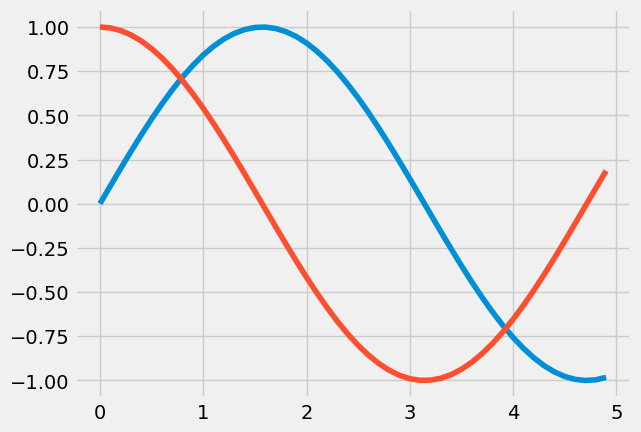

```python
plot_functions([math.sin, math.cos])
```

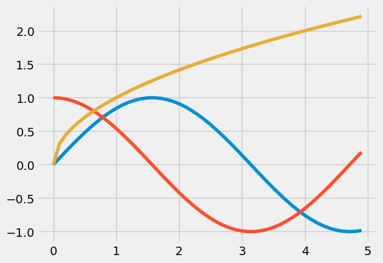

```python
plot_functions([math.sin, math.cos, math.sqrt])
```

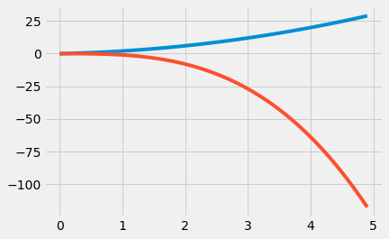

```python
# Let's plot some anonymous functions...
plot_functions([lambda a: a**2 + a, lambda b: -b**3])
```

Now let's plot some functions and their derivatives:

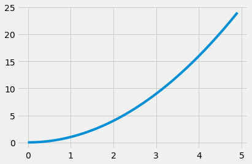

```python
plot_functions([lambda x: x**2])
```

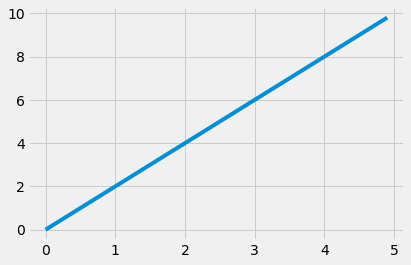

```python
plot_functions([deriv(lambda x: x**2)])
```

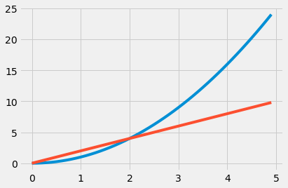

```python
plot_functions([lambda x: x**2, deriv(lambda x: x**2)])
```

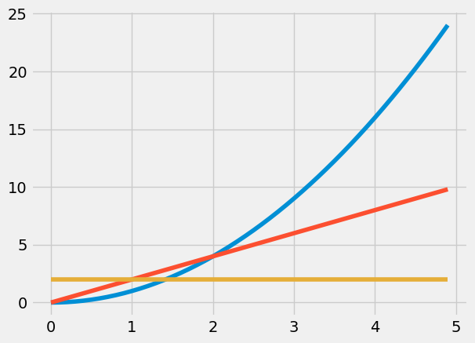

```python
def plot_deriv_1_2(f):
    f_prime = deriv(f)
    f_double_prime = deriv(f_prime)
    plot_functions([f,f_prime,f_double_prime])

plot_deriv_1_2(lambda x: x**2)
```

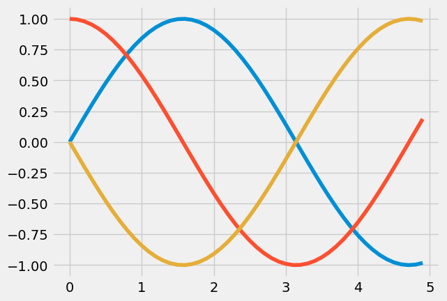

```python
plot_deriv_1_2(math.sin)
```

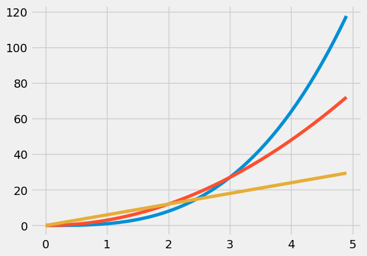

```python
plot_deriv_1_2(lambda x: x**3)
```

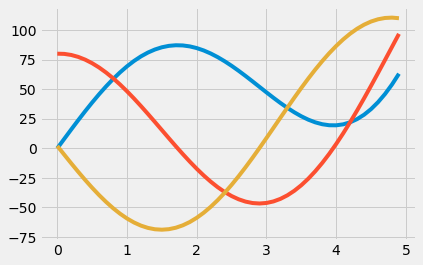

```python
plot_deriv_1_2(lambda x: x**3 + x**2 + 80*math.sin(x))
```

Before we move on from numerical derivatives, look how nicely function composition plays along in this system.

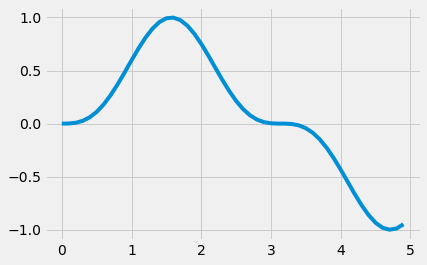

```python
plot_functions([compose(lambda x: x**3, math.sin)])
```

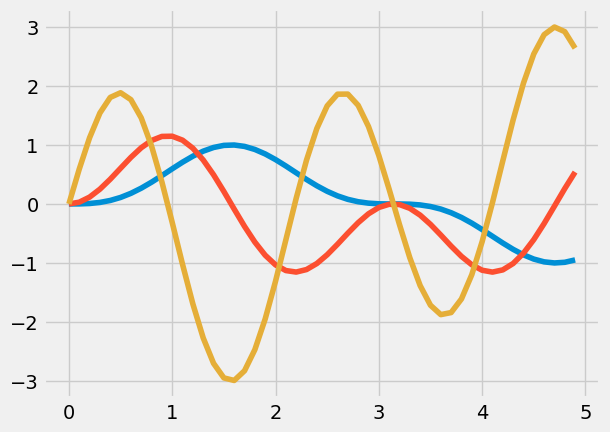

```python
plot_deriv_1_2(compose(lambda x: x**3, math.sin))
```

# Parameterized Types

Earlier, we made an `IntRoseTree` class that represented trees with *integers* as values at each node. But, there are many types of data we might want to store in trees: floating-point values (real numbers), strings, `Employee` objects in an organizational chart, etc.

With what we've seen so far, we would need to essentially copy all the code for the `IntRoseTree` to make a related version like `StringRoseTree`. The code would be substantially identical, merely replacing each occurrence of `IntRoseTree` with `StringRoseTree` and each occurrence of `int` with `str`. This would be tedious and error-prone, and flies in the face of our general goal of eliminating duplicate code wherever reasonably possible.

Fortunately, there is an alternative: type variables and generics. We've already used this idea extensively, without explicitly acknowledging it. Whenever we've made lists, dictionaries, or sets, we've accessed a variant of these for the specific type of contents we intend to store. There is a general *recipe* for making lists that can be applied for different element types, making it equally possible to make a `list[int]` as a `list[str]`. Similarly for `set` and `dict`. Each of these collections has not been made individually to anticipate the different types of things we might store, either: if we create a new class, we can make a list of objects of that class even though the people who wrote `list` never knew of this custom class.

Let's see how our `IntRoseTree` can expand to a more generic `RoseTree`:

- We make a *type variable*. This solves the problem of writing `int` in several places for our earlier `IntRoseTree`. Instead, we can make a tree whose values are of type `Alpha` for some `Alpha`, which could be `int`, `str`, or anything else. (Greek letters are often used for type variables to differentiate them from other types of variables.)
- We make a class that is *generic* and takes in a type variable as a *parameter*. This is not a parameter to one of its methods or to its constructor, but to the type itself. For instance, when we write `list[int]`, `int` is a parameter to the *type* `list` rather than to a function or method.

The following code demonstrates these principles:

```python
from typing import Callable, TypeVar, Generic
```

```python
Alpha = TypeVar("Alpha")

class RoseTree(Generic[Alpha]):

    _root: Alpha
    _children: list['RoseTree[Alpha]']

    def __init__(self, root: Alpha):
        self._root = root
        self._children = []

    @property
    def is_leaf(self) -> bool:
        return len(self._children)==0

    def add_child(self, child: 'RoseTree[Alpha]') -> None:
        self._children.append(child)

    def num_children(self) -> int:
        return len(self._children)

    def __repr__(self) -> str:
        if self.is_leaf:
            return f'{self._root}'
        else:
            return f'{self._root}[{self._children}]'

    def transform_imp(self, f: Callable[[Alpha],Alpha]) -> None:
        self._root = f(self._root)
        for child in self._children:
            child.transform_imp(f)

    def transform_func(self, f: Callable[[Alpha],Alpha]) -> 'RoseTree[Alpha]':
        t = RoseTree(f(self._root))
        for child in self._children:
            t.add_child(child.transform_func(f))
        return t
```

```python
def sample_tree() -> RoseTree[int]:
    t10: RoseTree[int]  = RoseTree(10)
    t50: RoseTree[int]  = RoseTree(50)
    t70: RoseTree[int]  = RoseTree(70)
    t20: RoseTree[int]  = RoseTree(20)
    t40: RoseTree[int]  = RoseTree(40)
    t90: RoseTree[int]  = RoseTree(90)
    t200: RoseTree[int] = RoseTree(200)
    t_40: RoseTree[int] = RoseTree(-40)
    t10.add_child(t50)
    t10.add_child(t70)
    t50.add_child(t20)
    t50.add_child(t40)
    t50.add_child(t90)
    t40.add_child(t200)
    t40.add_child(t_40)
    return t10
```

```python
t = sample_tree()
```

```python
print(t)
```

```
10[[50[[20, 40[[200, -40]], 90]], 70]]
```

```python
print(t.transform_func(lambda x: x * 3))
```

```
30[[150[[60, 120[[600, -120]], 270]], 210]]
```

```python
t2 = RoseTree("abc")
t2.add_child(RoseTree("def"))
```

```python
print(t2)
```

```
abc[[def]]
```

```python
print(t2.transform_func(lambda s: s.upper()))
```

```
ABC[[DEF]]
```

Now, we were able to make trees of different types without redundant code, and the string-based tree worked just as we might expect. Notice also that by being able to refer to `Alpha` in different places in the `RoseTree` class, we were able to *enforce* that `Alpha` is the same each time. For instance, a `RoseTree[int]` cannot be mixed with a `RoseTree[str]`, since `add_child` takes in a `RoseTree` with the *same* `Alpha`. (We'd use `mypy` to check this.)

```python
ts = RoseTree("P")
ti.add_child(ts)
```

rosetree.py:43: error: Argument 1 to "add_child" of "RoseTree" has incompatible type "RoseTree[str]"; expected "RoseTree[int]" [arg-type] Found 1 error in 1 file (checked 1 source file)

We enforce constraints whenever we use `Alpha` in our code. For instance, the `transform` methods guarantee that a new / updated `RoseTree` of the same type will be generated. But this limits us; could we `transform` from one type of tree to another? Using *two* type variables gives us a reasonable amount of added flexibility:

```python
from typing import Callable, TypeVar, Generic
```

```python
Alpha = TypeVar("Alpha")
Beta = TypeVar("Beta")

class RoseTree(Generic[Alpha]):

    _root: Alpha
    _children: list['RoseTree[Alpha]']

    def __init__(self, root: Alpha):
        self._root = root
        self._children = []

    @property
    def is_leaf(self) -> bool:
        return len(self._children)==0

    def add_child(self, child: 'RoseTree[Alpha]') -> None:
        self._children.append(child)

    def num_children(self) -> int:
        return len(self._children)

    def __repr__(self) -> str:
        if self.is_leaf:
            return f'{self._root}'
        else:
            return f'{self._root}[{self._children}]'

    def transform_imp(self, f: Callable[[Alpha],Alpha]) -> None:
        self._root = f(self._root)
        for child in self._children:
            child.transform_imp(f)

    def transform_func(self, f: Callable[[Alpha],Beta]) -> 'RoseTree[Beta]':
        t = RoseTree(f(self._root))
        for child in self._children:
            t.add_child(child.transform_func(f))
        return t
```

```python
t = RoseTree("abc")
t.add_child(RoseTree("defgh"))
```

```python
print(t)
```

```
abc[[defgh]]
```

```python
print(t.transform_func(lambda s: len(s)))
```

```
3[[5]]
```

Here, `len` is being used in a context where it is a `Callable[[str],int]`, and so it can be used to `transform_func` a `RoseTree[str]` to a `RoseTree[int]`.

Notice also that we cannot make `transform_imp` equally flexible, since that would require changing the type of an *existing* `RoseTree` rather than making a new one.

# Decorators

We've used decorators this quarter: `@property` and `@abstractmethod`, for instance. We write these above the definition of a function, and the decorator affects the behavior of the function in some way.

We now have the context to understand how these actually work:

- A decorator is actually a function that takes in a function and returns a modified function.
- When we use the `@D` syntax above a function `F`, it has the effect of applying `D` to (function) input `F` and determining the new function `D(F)`. Then, `F` is updated to really be `D(F)`.

Suppose we are suspicious of our factorial function and want to be able to debug it. As we talked about in the debugging lecture early in the quarter, we could add `print` statements to it, but that is tedious and it is tedious to later remove them. We could instead use a debugger. A third approach is to build a decorator that prints out a function's arguments and its return value. Having written this decorator once, we could use it over and over again on different functions, as needed.

The syntax for getting all of this to work is fairly technical. We will first show the code, then explain it:

```python
from typing import Callable, TypeVar, ParamSpec

Params = ParamSpec("Params")
Return = TypeVar("Return")

def instrument(f: Callable[Params, Return]) \
               -> Callable[Params, Return]:
    def instrumented(*args: Params.args,
                     **kwargs: Params.kwargs) -> Return:
        params = f"{f.__name__}({', '.join([str(arg) for arg in args])}) = "
        res: Return = f(*args)
        print(params + str(res))
        return res
    return instrumented
```

- We want this decorator to work with any function. A function is a `Callable`, but we do not know what the parameter or return types are. The `typing` module provides something called `ParamSpec` to allow us to essentially use a type variable for an entire parameter list instead of for only a single parameter.
- Recall that functions can have positional arguments: `f(a, b, c)`; and keyword arguments: `f(foo=a, bar=b)`. To work with any function, whether it uses one, the other, or both, we must make a decorator that supports both types of arguments.
- The verb *instrument* is often used in computer science to denote taking a piece of code and adding something to record its behavior in some way. Typically, when instrumenting, we do not want to change the behavior of a function, leaving all the code that relies on it intact and oblivious to the instrumentation, but for the fact that the instrumentation is recording information somewhere else for later analysis. We can do this for correctness debugging or for performance debugging.
- The `instrument` decorator takes in a function `f` that is a completely generic function (in the sense that it could be any function): it is a `Callable` that takes in any specific combination of parameters (`Params`) and returns some specific return type (`Return`). The `instrument` method will return a function with the exact same type, in other words, the exact same set of parameters and the exact same return type. By applying `instrument` to a function, you should not be able to observe that it is different, based on its type.
- A decorator needs to return an updated function. This updated function will be complex enough that a `lambda` will not be suitable, so we will make an inner function and return it.
- The inner function does not know what the exact parameters will be. The syntax shown here is flexible in that it is a special way to accept any set of positional arguments (`*args`) and keyword arguments (`**kwargs`). The former is a list of the positional arguments and the latter is a dictionary of the keyword arguments. Their types can be retrieved from `Params` as you see us doing here.
- For simplicity, we will ignore the keyword arguments in this example, other than the bare minimum to make the types work.
- We then generate a string with the function name and the parameter values.
- Next, we actually call the function and save its return value.
- Then, we print the string with the parameters and the return produced by the function.
- Finally, we also return the result value to the actual caller of the function so they can behave as if no instrumentation is being performed. From the standpoint of this code, the function being called behaves as it always did, even without the instrumentation.
- A point of interest is that we turn the input parameters to a string before calling the function. This is a good idea because the function might modify the values of its inputs, so it could be misleading if we printed the values of its inputs *after* calling it.

Let's see this in action with a broken factorial function:

```python
from typing import Callable, TypeVar, ParamSpec

Params = ParamSpec("Params")
Return = TypeVar("Return")

def instrument(f: Callable[Params, Return]) \
               -> Callable[Params, Return]:
    def instrumented(*args: Params.args,
                     **kwargs: Params.kwargs) -> Return:
        params = f"{f.__name__}({', '.join([str(arg) for arg in args])}) = "
        res: Return = f(*args)
        print(params + str(res))
        return res
    return instrumented
```

```python
@instrument
def factorial(n: int) -> int:
    if n < 0:
        return 1
    return n * factorial(n - 1)
```

```python
factorial(5)
```

```
factorial(-1) = 1
factorial(0) = 0
factorial(1) = 0
factorial(2) = 0
factorial(3) = 0
factorial(4) = 0
factorial(5) = 0
```

```
0
```